# R Notebook

Contoh 1. Seorang peneliti telah mengumpulkan data tentang tiga variabel psikologis, empat variabel akademik (nilai tes standar) dan jenis kelamin untuk 600 mahasiswa baru. Dia tertarik pada bagaimana himpunan variabel psikologis berhubungan dengan variabel akademik dan gender. Secara khusus, peneliti tertarik pada berapa banyak dimensi (variabel kanonik) yang diperlukan untuk memahami hubungan antara dua set variabel.

Contoh 2. Seorang peneliti tertarik untuk mengeksplorasi hubungan antar faktor dari dua tes kepribadian multidimensi, MMPI dan NEO. Dia tertarik pada dimensi apa yang umum di antara tes dan berapa banyak varians yang dibagi di antara keduanya. Dia secara khusus tertarik untuk menemukan apakah dimensi neurotisme dari NEO dapat menjelaskan sejumlah besar varian bersama antara kedua tes tersebut.

```r
require(ggplot2)
require(GGally)
require(CCA)
require(CCP)
```

```r
mm <- read.csv("https://stats.idre.ucla.edu/stat/data/mmreg.csv")
colnames(mm) <- c("Control", "Concept", "Motivation", "Read","Write", "Math", "Science", "Sex")
summary(mm)
```

```
    Control            Concept            Motivation
 Min.   :-2.23000   Min.   :-2.620000   Min.   :0.0000
 1st Qu.:-0.37250   1st Qu.:-0.300000   1st Qu.:0.3300
 Median : 0.21000   Median : 0.030000   Median :0.6700
 Mean   : 0.09653   Mean   : 0.004917   Mean   :0.6608
 3rd Qu.: 0.51000   3rd Qu.: 0.440000   3rd Qu.:1.0000
 Max.   : 1.36000   Max.   : 1.190000   Max.   :1.0000
      Read          Write            Math          Science
 Min.   :28.3   Min.   :25.50   Min.   :31.80   Min.   :26.00
 1st Qu.:44.2   1st Qu.:44.30   1st Qu.:44.50   1st Qu.:44.40
 Median :52.1   Median :54.10   Median :51.30   Median :52.60
 Mean   :51.9   Mean   :52.38   Mean   :51.85   Mean   :51.76
 3rd Qu.:60.1   3rd Qu.:59.90   3rd Qu.:58.38   3rd Qu.:58.65
 Max.   :76.0   Max.   :67.10   Max.   :75.50   Max.   :74.20
      Sex
 Min.   :0.000
 1st Qu.:0.000
 Median :1.000
 Mean   :0.545
 3rd Qu.:1.000
 Max.   :1.000
```

```r
mm
```

| Control | Concept | Motivation | Read | Write | Math | Science | Sex |
| --- | --- | --- | --- | --- | --- | --- | --- |
| -0.84 | -0.24 | 1.00 | 54.8 | 64.5 | 44.5 | 52.6 | 1 |
| -0.38 | -0.47 | 0.67 | 62.7 | 43.7 | 44.7 | 52.6 | 1 |
| 0.89 | 0.59 | 0.67 | 60.6 | 56.7 | 70.5 | 58.0 | 0 |
| 0.71 | 0.28 | 0.67 | 62.7 | 56.7 | 54.7 | 58.0 | 0 |
| -0.64 | 0.03 | 1.00 | 41.6 | 46.3 | 38.4 | 36.3 | 1 |
| 1.11 | 0.90 | 0.33 | 62.7 | 64.5 | 61.4 | 58.0 | 1 |
| 0.06 | 0.03 | 0.67 | 41.6 | 39.1 | 56.3 | 45.0 | 0 |
| -0.91 | -0.59 | 0.67 | 44.2 | 39.1 | 46.3 | 36.3 | 0 |
| 0.45 | 0.03 | 1.00 | 62.7 | 51.5 | 54.4 | 49.8 | 1 |
| 0.00 | 0.03 | 0.67 | 62.7 | 64.5 | 38.3 | 55.8 | 1 |

[output cut: 590 more lines]

```r
xtabs(~Sex, data = mm)
```

```
Sex
  0   1
273 327
```

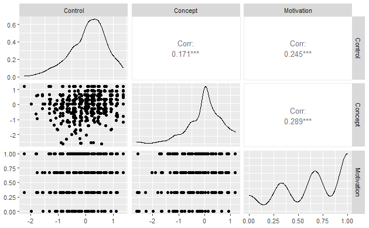

```r
psych <- mm[, 1:3]
acad <- mm[, 4:8]

ggpairs(psych)
```

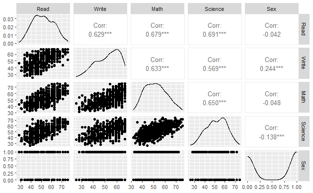

```r
ggpairs(acad)
```

```r
matcor(psych, acad)
```

```
$Xcor
             Control   Concept Motivation
Control    1.0000000 0.1711878  0.2451323
Concept    0.1711878 1.0000000  0.2885707
Motivation 0.2451323 0.2885707  1.0000000

$Ycor
               Read     Write       Math    Science         Sex
Read     1.00000000 0.6285909  0.6792757  0.6906929 -0.04174278
Write    0.62859089 1.0000000  0.6326664  0.5691498  0.24433183
Math     0.67927568 0.6326664  1.0000000  0.6495261 -0.04821830
Science  0.69069291 0.5691498  0.6495261  1.0000000 -0.13818587
Sex     -0.04174278 0.2443318 -0.0482183 -0.1381859  1.00000000

$XYcor
             Control     Concept Motivation        Read
Control    1.0000000  0.17118778 0.24513227  0.37356505
Concept    0.1711878  1.00000000 0.28857075  0.06065584
Motivation 0.2451323  0.28857075 1.00000000  0.21060992
Read       0.3735650  0.06065584 0.21060992  1.00000000
Write      0.3588768  0.01944856 0.25424818  0.62859089
Math       0.3372690  0.05359770 0.19501347  0.67927568
Science    0.3246269  0.06982633 0.11566948  0.69069291
Sex        0.1134108 -0.12595132 0.09810277 -0.04174278
                Write       Math     Science         Sex
Control    0.35887684  0.3372690  0.32462694  0.11341075
Concept    0.01944856  0.0535977  0.06982633 -0.12595132
Motivation 0.25424818  0.1950135  0.11566948  0.09810277
Read       0.62859089  0.6792757  0.69069291 -0.04174278
Write      1.00000000  0.6326664  0.56914983  0.24433183
Math       0.63266640  1.0000000  0.64952612 -0.04821830
Science    0.56914983  0.6495261  1.00000000 -0.13818587
Sex        0.24433183 -0.0482183 -0.13818587  1.00000000
```

```r
cc1 <- cc(psych, acad)
# display the canonical correlations
cc1$cor
```

```
[1] 0.4640861 0.1675092 0.1039911
```

dua dari tiga dimensi kanonik secara statistik signifikan pada tingkat 0,05. Dimensi 1 memiliki kanonik korelasi 0,46 antara set variabel, sedangkan untuk dimensi 2 korelasi kanonik jauh lebih rendah pada 0,17.

```r
# raw canonical coefficients
cc1[3:4]
```

```
$xcoef
                 [,1]       [,2]       [,3]
Control    -1.2538339 -0.6214776 -0.6616896
Concept     0.3513499 -1.1876866  0.8267210
Motivation -1.2624204  2.0272641  2.0002283

$ycoef
                [,1]         [,2]         [,3]
Read    -0.044620600 -0.004910024  0.021380576
Write   -0.035877112  0.042071478  0.091307329
Math    -0.023417185  0.004229478  0.009398182
Science -0.005025152 -0.085162184 -0.109835014
Sex     -0.632119234  1.084642326 -1.794647036
```

Peningkatan satu unit dalam read menyebabkan penurunan sebesar 0,0446 dalam variat kanonik pertama dari himpunan 2 ketika variabel lainnya dipertahankan konstan. Menjadi perempuan mengarah pada penurunan 0,6321 dalam dimensi 1 untuk kumpulan akademik dengan prediktor lain dianggap konstan

```r
# compute canonical loadings
cc2 <- comput(psych, acad, cc1)

# display canonical loadings
cc2[3:6]
```

```
$corr.X.xscores
                  [,1]       [,2]       [,3]
Control    -0.90404631 -0.3896883 -0.1756227
Concept    -0.02084327 -0.7087386  0.7051632
Motivation -0.56715106  0.3508882  0.7451289

$corr.Y.xscores
              [,1]        [,2]        [,3]
Read    -0.3900402 -0.06010654  0.01407661
Write   -0.4067914  0.01086075  0.02647207
Math    -0.3545378 -0.04990916  0.01536585
Science -0.3055607 -0.11336980 -0.02395489
Sex     -0.1689796  0.12645737 -0.05650916

$corr.X.yscores
                   [,1]        [,2]        [,3]
Control    -0.419555307 -0.06527635 -0.01826320
Concept    -0.009673069 -0.11872021  0.07333073
Motivation -0.263206910  0.05877699  0.07748681

$corr.Y.yscores
              [,1]        [,2]       [,3]
Read    -0.8404480 -0.35882541  0.1353635
Write   -0.8765429  0.06483674  0.2545608
Math    -0.7639483 -0.29794884  0.1477611
Science -0.6584139 -0.67679761 -0.2303551
Sex     -0.3641127  0.75492811 -0.5434036
```

```r
# tests of canonical dimensions
rho <- cc1$cor
## Define number of observations, number of variables in first set, and number of variables in the second set.
n <- dim(psych)[1]
p <- length(psych)
q <- length(acad)

## Calculate p-values using the F-approximations of different test statistics:
p.asym(rho, n, p, q, tstat = "Wilks")
```

```
Wilks' Lambda, using F-approximation (Rao's F):
              stat    approx df1      df2     p.value
1 to 3:  0.7543611 11.715733  15 1634.653 0.000000000
2 to 3:  0.9614300  2.944459   8 1186.000 0.002905057
3 to 3:  0.9891858  2.164612   3  594.000 0.091092180
```

```r
p.asym(rho, n, p, q, tstat = "Hotelling")
```

```
 Hotelling-Lawley Trace, using F-approximation:
               stat    approx df1  df2     p.value
1 to 3:  0.31429738 12.376333  15 1772 0.000000000
2 to 3:  0.03980175  2.948647   8 1778 0.002806614
3 to 3:  0.01093238  2.167041   3 1784 0.090013176
```

```r
p.asym(rho, n, p, q, tstat = "Pillai")
```

```
 Pillai-Bartlett Trace, using F-approximation:
               stat    approx df1  df2     p.value
1 to 3:  0.25424936 11.000571  15 1782 0.000000000
2 to 3:  0.03887348  2.934093   8 1788 0.002932565
3 to 3:  0.01081416  2.163421   3 1794 0.090440474
```

```r
p.asym(rho, n, p, q, tstat = "Roy")
```

```
 Roy's Largest Root, using F-approximation:
              stat   approx df1 df2 p.value
1 to 1:  0.2153759 32.61008   5 594       0

 F statistic for Roy's Greatest Root is an upper bound.
```

Seperti yang ditunjukkan pada tabel di atas, pengujian pertama dimensi kanonis menguji apakah ketiga dimensi tersebut signifikan (yaitu, F = 11,72), pengujian berikutnya menguji apakah kombinasi dimensi 2 dan 3 signifikan (yaitu, F = 2,94) . Terakhir, tes terakhir menguji apakah dimensi 3 dengan sendirinya signifikan (tidak). Oleh karena itu dimensi 1 dan 2 masing-masing harus signifikan sedangkan dimensi tiga tidak.

Ketika variabel dalam model memiliki standar deviasi yang sangat berbeda, koefisien standar memungkinkan perbandingan yang lebih mudah antar variabel. Selanjutnya, kami akan menghitung koefisien kanonik standar.

```r
# standardized psych canonical coefficients diagonal matrix of psych sd's
s1 <- diag(sqrt(diag(cov(psych))))
s1 %*% cc1$xcoef
```

```
           [,1]       [,2]       [,3]
[1,] -0.8404196 -0.4165639 -0.4435172
[2,]  0.2478818 -0.8379278  0.5832620
[3,] -0.4326685  0.6948029  0.6855370
```

```r
# standardized acad canonical coefficients diagonal matrix of acad sd's
s2 <- diag(sqrt(diag(cov(acad))))
s2 %*% cc1$ycoef
```

```
            [,1]        [,2]        [,3]
[1,] -0.45080116 -0.04960589  0.21600760
[2,] -0.34895712  0.40920634  0.88809662
[3,] -0.22046662  0.03981942  0.08848141
[4,] -0.04877502 -0.82659938 -1.06607828
[5,] -0.31503962  0.54057096 -0.89442764
```

Untuk variabel psikologis, dimensi kanonik pertama paling kuat dipengaruhi oleh locus of control (-.84) dan untuk dimensi kedua konsep diri (-.84) dan motivasi (.69). Untuk variabel akademik ditambah jenis kelamin, dimensi pertama terdiri dari membaca (-.45), menulis (-.35) dan jenis kelamin (-.32). Untuk penulisan dimensi kedua (0,41), sains (-,83) dan jenis kelamin (0,54) adalah variabel yang mendominasi.